# Reproducible Research: Course Project 1

### Loading and preprocessing the data

Data was read-in as comma-separated values. The only pre-processing required was to unzip the activity data file provided in the repository:

```r
unzipped_data <- unzip("activity.zip")
data <- read.csv(unzipped_data, header = TRUE)
```

### What is mean total number of steps taken per day?

I first calculated the total number of steps per day (ignoring missing values), and plotted a histogram of the resulting data, as follows:

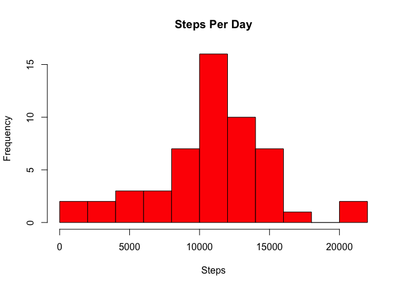

```r
steps_per_day <- data %>% group_by(date) %>% summarise(steps = sum(steps))
hist(steps_per_day$steps, main = "Steps Per Day", xlab = "Steps", col = "red", breaks = 10)
```

Now I calculated the mean and median total number of steps taken per day:

```r
mean_steps_per_day <- mean(steps_per_day$steps, na.rm = TRUE)
median_steps_per_day <- median(steps_per_day$steps, na.rm = TRUE)
c(mean_steps_per_day, median_steps_per_day)
```

```
## [1] 10766.19 10765.00
```

### What is the average daily activity pattern?

To address this question I made a time series plot (i.e. type = “l”) of the 5-minute interval (x-axis) and the average number of steps taken, averaged across all days (y-axis), as follows:

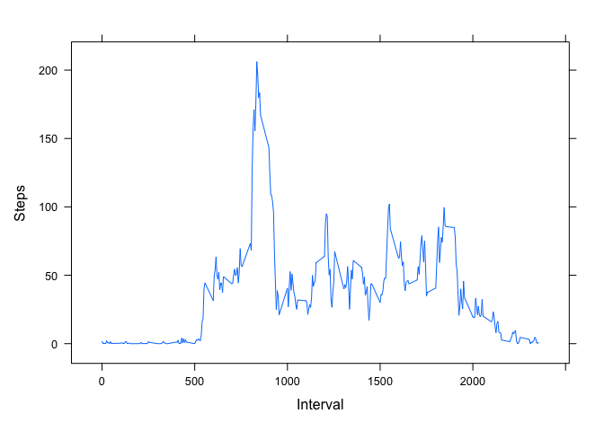

```r
avg_steps_per_interval <- data %>% group_by(interval) %>% summarise(steps = mean(steps, na.rm = TRUE))
xyplot(avg_steps_per_interval$steps ~ avg_steps_per_interval$interval, type = "l", xlab = "Interval", ylab = "Steps")
```

Next I answered the question “Which 5-minute interval, on average across all the days in the dataset, contains the maximum number of steps?”:

```r
max_steps = max(avg_steps_per_interval$steps)
avg_steps_per_interval %>% filter(steps==max_steps) %>% pull(interval)
```

```
## [1] 835
```

### Imputing missing values

```r
sum(is.na(data$steps))
```

```
## [1] 2304
```

Secondly I devised a strategy for filling in the missing values in the dataset and created a new dataset with the missing data filled in, as follows:

```r
imputed_data <- data %>% group_by(interval) %>% mutate(steps = replace(steps, is.na(steps), as.integer(round(mean(steps, na.rm = TRUE)))))
```

I chose to use the mean for the 5-minute interval as using mean for that day doesn’t really work ( because for some days all the steps are NA’s). In order to maintain the original data type in the ‘steps’ column, I rounded the ‘mean steps per interval’ before converting it to the integer type.

Next I made a histogram of the total number of steps taken each day:

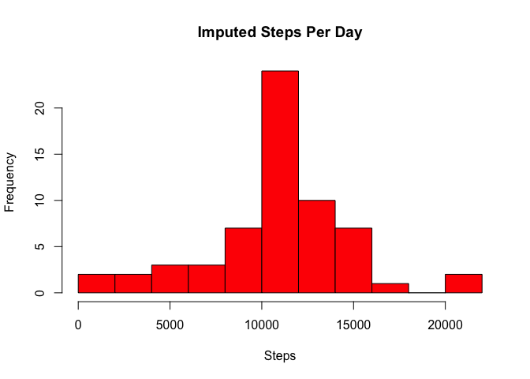

```r
imputed_steps_per_day <- imputed_data %>% group_by(date) %>% summarise(steps = sum(steps))
hist(imputed_steps_per_day$steps, main = "Imputed Steps Per Day", xlab = "Steps", col = "red", breaks = 10)
```

I then calculated and reported the mean and median total number of steps taken per day:

```r
imputed_mean_steps_per_day <- mean(imputed_steps_per_day$steps, na.rm = TRUE)
imputed_median_steps_per_day <- median(imputed_steps_per_day$steps, na.rm = TRUE)
```

I next compared whether these these values differ from the estimates in the first part of the assignment, by plotting the histograms side-by-side.

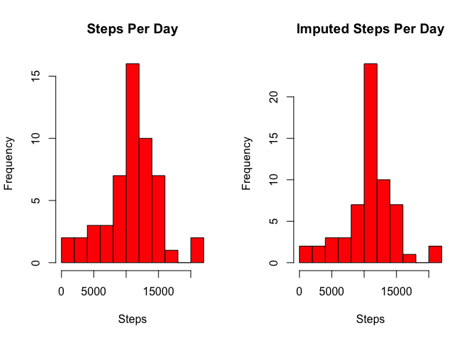

```r
par(mfrow=c(1,2))
hist(steps_per_day$steps, main = "Steps Per Day", xlab = "Steps", col = "red", breaks = 10)
hist(imputed_steps_per_day$steps, main = "Imputed Steps Per Day", xlab = "Steps", col = "red", breaks = 10)
```

```r
mean_median_comparison <- data.frame(original = c(mean_steps_per_day, median_steps_per_day), imputed = c(imputed_mean_steps_per_day, imputed_median_steps_per_day), row.names = c("mean", "median"))
kable(mean_median_comparison)
```

|  | original | imputed |
| --- | --- | --- |
| mean | 10766.19 | 10765.64 |
| median | 10765.00 | 10762.00 |

Using imputed values results in a slight decrease in both mean and median steps. For mean steps the drop is 0.55 (of a step) and for median steps the decrease is 3 steps.

### Are there differences in activity patterns between weekdays and weekends?

To answer this question I create a new factor variable in the dataset with two levels, indicating whether a given date is a weekday or weekend day. This was added to the previous created dataset filled-in missing values, as follows:

```r
weekdays <- c("Monday", "Tuesday", "Wednesday", "Thursday", "Friday")
week_data <- imputed_data %>% mutate(timeofweek = weekdays(as.Date(date))) %>% mutate(timeofweek = ifelse(timeofweek %in% weekdays, "weekday", "weekend"))
```

Finally I made a comparative time series plot of the 5-minute interval (x-axis) and the average number of steps taken, averaged across all weekday days or weekend days (y-axis).

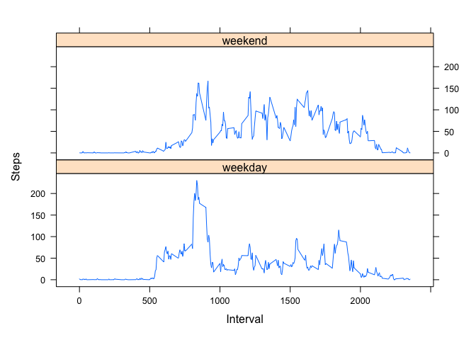

```r
avg_steps_by_timeofweek <- week_data %>% group_by(interval, timeofweek) %>% summarise(meansteps = mean(steps, na.rm = TRUE), .groups = "keep")
plot <- xyplot(avg_steps_by_timeofweek$meansteps ~ avg_steps_by_timeofweek$interval | avg_steps_by_timeofweek$timeofweek,
       layout = c(1, 2), type = "l",
       xlab = "Interval", ylab = "Steps")
print(plot)
```